# Module 1: Fish and heavy metal contaminants

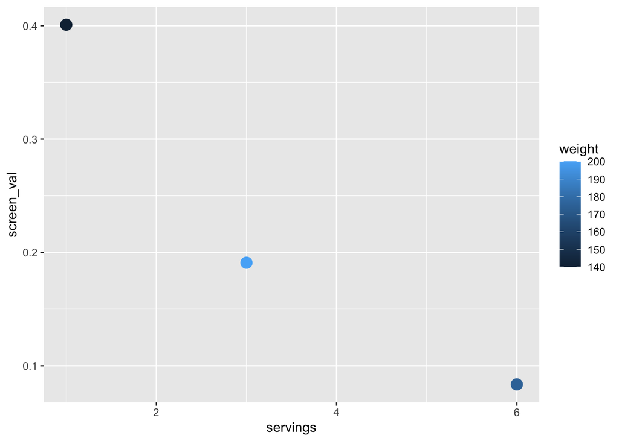

```r
ggplot(data=sv_df,
        aes(x=servings, y=screen_val, col=weight)) +
    geom_point(size=4)
```

We can also change the `theme`, which alters the background and style of our plot.

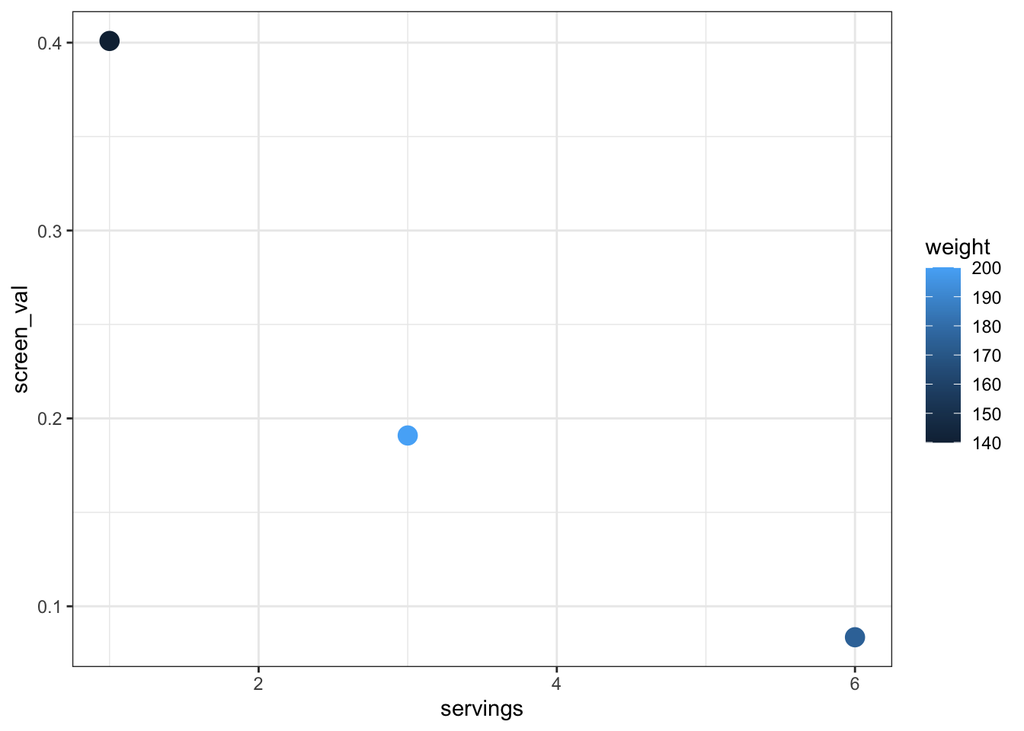

```r
ggplot(data=sv_df,
        aes(x=servings, y=screen_val, col=weight)) +
    geom_point(size=4) +
  theme_bw()
```

Finally we can add a title and change the labels to be more descriptive using `labs()`.

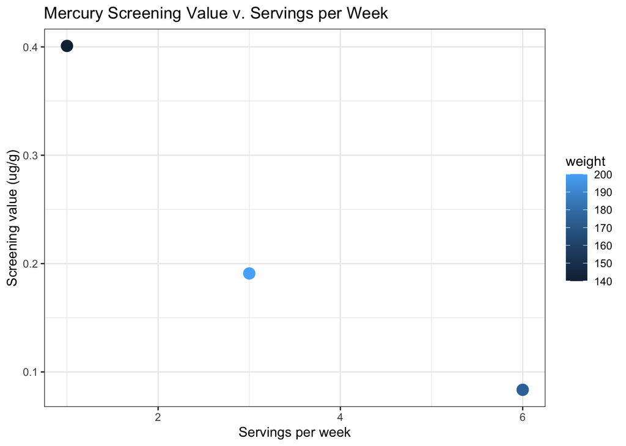

```r
ggplot(data=sv_df,
        aes(x=servings, y=screen_val, col=weight)) +
    geom_point(size=4) +
    theme_bw() +
    labs(x="Servings per week", y="Screening value (ug/g)", title="Mercury Screening Value v. Servings per Week")
```

You should start to see a relationship between servings per week and screening value, but there are only 3 data points included above. Run the following code to create a similar plot with more data and get a better idea of the relationship between weight, servings per week, and screening value.

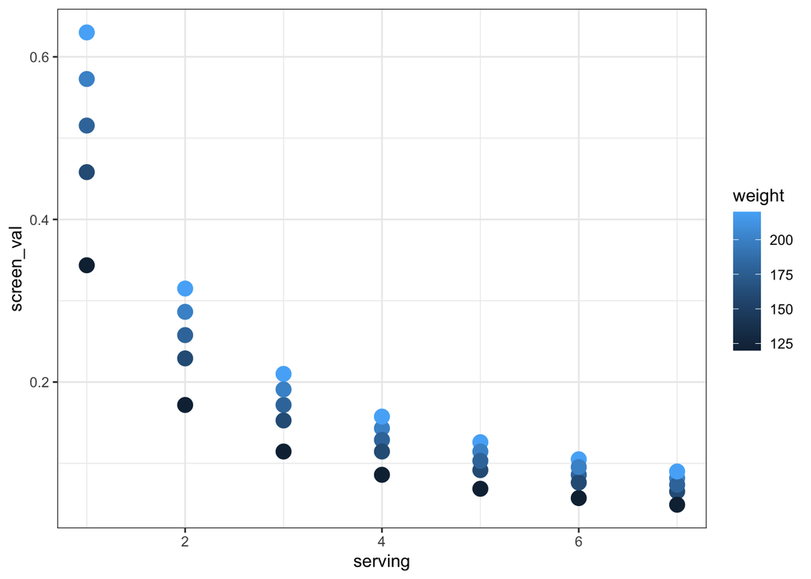

```r
weight = rep(c(120, 160, 180, 200, 220), 7)
serving = rep(seq(1:7), 5)
sv_df_long = data.frame(weight, serving)
sv_df_long$screen_val = RfD*sv_df_long$weight*0.45/(110*sv_df_long$serving/7)

ggplot(sv_df_long) + geom_point(aes(x=serving, y=screen_val, col=weight), size=4) +
  theme_bw()
```

**Class Questions**

- How would you describe this graph and the relationship between screening value, consumption rate, and weight? What happens to the distribution in screening values as the number of servings per week increase?
- With this information in mind, consider how to make decisions with the data on mercury content in fish – how should we consider the screening value for different ages? For example, what screening value would be safer for children, who weigh less than the average adult?

### Lesson 1.1 Recap

In this lesson we have learned to:

- define and print() an object in R
- use R for equations
- create a vector and a data frame
- visualize data with ggplot()
- describe the relationsihp between weight, servings of fish, and screening values of mercury

## Lesson 1.2: Loading in and exploring the data

**Now we will load in the dataset for the physical fish data**

These data are the length and methyl mercury content of fish caught on the K’Avi reservation in 1998, soon after the polluting factory was shut down.

- Each row is data from one fish.
- The first column “length” is the length of the fish in cm.
- The second column “mercury” is the concentration of methylmercury (a poison) in the fish, in units of micrograms (ug) of methylmercury per gram of fish (g).

```r
fish_1998 <- read.csv("fish_1998.csv", header = TRUE, sep = ',')
```

Let’s break down the different parts of what just happened:

### Previewing the data

- Look through these data to see if they make sense (any weird numbers? Any missing data?).
- Then close that tab and come back to this window.

**A shorthand way to view the data**

If we don’t want to look at all of the data and instead just want to see what is going on in the first couple rows we can use the following code.

The command head() shows the column names and the first few rows of the data

```r
head(fish_1998)
```

```
##   X   length   mercury
## 1 1 45.21643 0.4315457
## 2 2 44.34876 0.4969477
## 3 3 46.86563 0.4491865
## 4 4 41.67329 0.4137213
## 5 5 51.34514 0.7491135
## 6 6 56.66428 0.6807240
```

**Class Questions:**

- What are the columns in the R dataframe called fish_1998?
- What sorts of questions could the tribal fishery managers answer with this data?

### Exploring the dimensions of the data

To answer these questions, it would be helpful to know how many fish have methyl mercury measurements.We can very quickly find that out with the following code.

The command `dim()` shows the dimension of the dataset. “Dimension” is the number of rows & number of columns.

```r
dim(fish_1998) #shows the dimensions of the dataset, which will be important later on
```

```
## [1] 300   3
```

**Class Question:**

- How many fish did the managers measure mercury on in 1998?

### Lesson 1.2 Recap

You now know the basic ways to look at and understand your data in R, which will come in handy any time you use R in the future.This included:

- Load a csv file as a data frame using `read.csv()`
- Preview the data frame using `head()`, `str()`
- Identify number of rows and columns using `dim()`

## Lesson 1.3: Calculating descriptive statistics

Recall the maximum safe level of mercury to consume depends on how often fish are being consumed, and weight of person. According to the EPA, the maximum safe level of mercury to be consumed is around 0.46 ug/g/day if not frequently consuming fish.

Tribal fishery managers are interested in whether the mercury levels in local fish belly fat exceeds this amount. They are also interested in if the amount of mercury in fish is connected to fish size.

Below, we will analyze data points from the “fish” data set to try and answer these questions.

### Descriptive statistics: mean v. median

**What is the mean (average) amount of mercury found in local fish?**

```r
# Below, we will use "$" to select the column called "mercury" in the data
# If we wanted the mean fish length, we;d have written mean(fish_1998$length)

mean(fish_1998$mercury)
```

```
## [1] 0.4481177
```

The “mean” is the average level of mercury in the data.

**Class Questions:**

- Why would knowing the mean (average) amount of methylmercury in fish be useful for fishery managers and the community?

The “median” is the middle level of mercury data (half the fish in the dataset have more mercury and half have less).

- Means and medians are often similar, However:
  - They will be different if the data have a lot of large values or a lot of small valued (skewed data).
  - Sometimes you are asked to use one or the other, so it’s good to be careful about which you are calculating.

```r
# remember, in the last code chunk, we used mean(fish_1998$mercury)
# The code below is similar, but it calculates the median.

median(fish_1998$mercury)
```

```
## [1] 0.4135396
```

**Class Question:**

- How would we interpret these median and mean values? Should the K’avi community be concerned?

**Your turn**

Work in groups to see if you can find these values using the commands `max()` and `min()`

For help, you can google “R min()” or you can type `?min()` in the “Console” window below, then read the help file in the “Output” window on the lower right.

```r
# Type your code below to calculate the mininum and maximum values of methylemercury in the 1998 fish dataset.
```

**Class Question**

- What are the minimum and maximum levels of mercury for fish in 1998?
- How would we interpret these values? Are they as important as the average?

### Summarizing data

The mean, median, minimum and maximum are all “descriptive statistics.” This means that they provide key information about the distribution of data. Here, we want to know the distribution of mercury in fish collected in 1998.

The function `summary()` estimates all these descriptive statsitics and more.

```r
# The format of this summary() command is similar to other commands.
summary(fish_1998$mercury)
```

```
##     Min.  1st Qu.   Median     Mean  3rd Qu.     Max.
## 0.007764 0.278103 0.413540 0.448118 0.557474 1.894938
```

1st Qu. and 3rd Qu. refer to the 1st and 3rd “Quartiles”, which represent a quarter of the data. They tell you that 25% of the data is between that value, the Median, and either the Min. (1st Qu.) or Max. (3rd Qu.).

**Class Question:**

- We have already explored how unsafe levels of mercury depend on consumption rates, and that the FDA recommends avoiding anything above 0.46 μg/g/day. At what point in the distribution does the screening value exceed 0.46 μg/g/day?

### Lesson 1.3 Recap

In Lesson 1.3 we learned how to:

- get descriptive statistics for a vector
- interpret the summary statistics for our data set

#### How could we communicate these values?

However, summary stats can’t answer every question, and as a list of numbers they would be very difficult to communicate to the K’avi community. It would be much more helpful to visualize the data in a graph, which we will do in the next part.

## Lesson 1.4: Plotting mercury concentrations with ggplot

We want to first visualize the amount of mercury in all the fish, or a distribution of the mercury data.

We can do this by creating graphs!

If you run the code chunk below, it will make a graph of all the 1998 mercury data. We want to see the distributions of mercury in the fish to learn how common it is for fish to have mercury levels above the EPA’s recommended safe level.

This code has a lot of details that we will work through later. For now, you can either just run the code chunk (by clicking the small green arrow in the upper right corner of the grey area), or you can explore the code line by line. We’ve provided some comments to help you out. [This cheatsheet](https://images.datacamp.com/image/upload/v1666806657/Marketing/Blog/ggplot2_cheat_sheet.pdf) will also give you some tips.

### Plot distribution of 1 variable

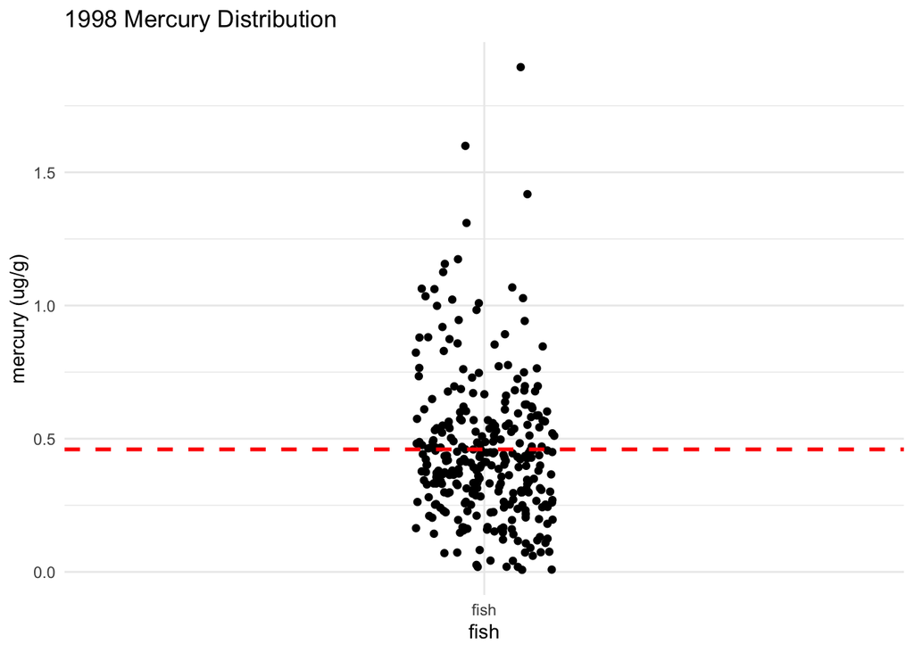

```r
#For this plot, we want to see the distributions of mercury in the fish and how many of them are above the EPA's recommended levels
#ggplot is the function that we are using to create a plot. aes() is used to tell ggplot what we want to see on each axis, in this case x= 'fish' and y= mercury. x="fish" indicates that the x axis doesn't have a variable and is titled fish. This allows us to look at the variation in lengths of fish independent of another variable.
ggplot (fish_1998, aes(x= 'fish', y= mercury))+
#Since ggplot is just a function to create plots, we need to further specify what kind of plot it should create. We can do this by using the geom_jitter function, which will create the jitter plot seen below. We can also add a few more parameters to the graph, such as changing the width of the points (width = 0.1).
#The jitter plot is a variation on the scatterplot, but it separates the data so that we can distinguish how many points are above the unsafe mercury level. To see the difference, try geom_point() and then geom_jitter()
  geom_jitter(width = 0.1)+
#We can also add shapes to the plot. Here we added a line to show where  the EPA's guideline for unsafe levels of mercury in fish would fall. To create  this we used the geom_hline() function which simply creates a horizontal line at a y-intercept that you set. We can also adjust the color and appearance of the line with color = 'red'.
  geom_hline(yintercept = 0.46, linetype= "dashed", color= "red", size=1)+
#This allows us to relabel the x-axis
  xlab("fish")+
#This allows us to relabel the y-axis
  ylab("mercury (ug/g)")+
#This allows us to title the graph
  ggtitle("1998 Mercury Distribution")+
#This adjusts the non-data components of the plot, so the titles, labels, background, and legends among other aspects.
  theme_minimal()
```

**Class question:**

- What does this distribution tell us about the mercury levels in the fish?

### Boxplots: distribution of 1 variable

Next, Look back at the min, max, median, and mean values that were calculated above. Where would these values fall on this graph? Are the mean and median values above or below the level suggested by the EPA?

Like last time, you can just run this code if you want. We want to focus on the results. However, we’ve provided comments to help you understand each line of the code, if you want.

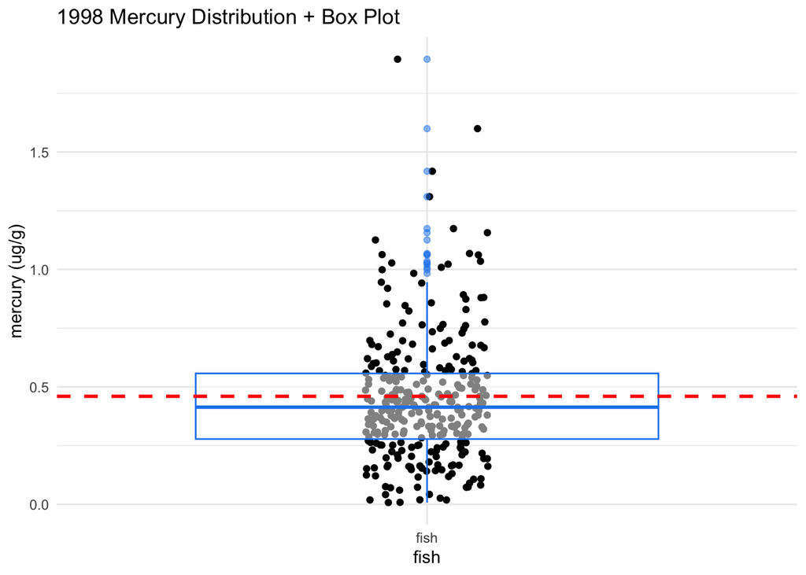

```r
# These lines are almost the same as the last code chunk,
# but we added a '+' at the end, to add some new pieces to the graph.
ggplot (fish_1998, aes(x= 'fish', y= mercury))+
geom_jitter(width = 0.1)+
# We will overlay a boxplot on the jitter plot.
# We can adjust its color as we did above,
# We use alpha, to adjust the opacity of the boxplot.
# This lets us see the jitter plot beneath it.
geom_boxplot(alpha=0.5, color="dodgerblue2")+
# As before, we add a line to represent the EPA's recommended safe mercury ingestion level
geom_hline(yintercept = 0.46, linetype= "dashed", color= "red", size=1)+
# The rest of the code is the same as the last code chunk:
  xlab("fish")+
  ylab("mercury (ug/g)")+
  ggtitle("1998 Mercury Distribution + Box Plot")+
theme_minimal()
```

You have now seen what the mercury distribution in local fish looks like and connected it to the summary statistics that were calculated above!

**Class Questions:**

- From looking at this graph, are there unsafe levels of mercury in local fish? If so, is it in most fish, or only some? Did this graph tell you anything different than the summary statistics, or did it just tell you the same information in a different way?
- In 1998, was it safe for members of the K’avi community to eat fish from these waters?
- How comfortable would you have been in 1998 about eating a fish that you caught?

### Scatterplots: Plot relationship between 2 variables

Mercury is known to build up in fish as they age: The oldest fish tend to have the highest levels of mercury. Older fish also tend to be bigger, so maybe if we know the relationship between fish size and fish mercury levels, that could give us useful guidance for which fish were safe to eat back in 1998.

We’ll make another graph of the same dataset. This time we’ll make a scatterplot of both the mercury level and the length of each fish. A scatterplot shows the data as points in two dimensions (fish length and mercury content, here).

Again, you can just run the code (with the green arrow), but we’ve also provided comments to help you learn how it works. Our goal here is to let you see the kings of graphs you can make in R and to help interpret the safety of the fish from 1998.

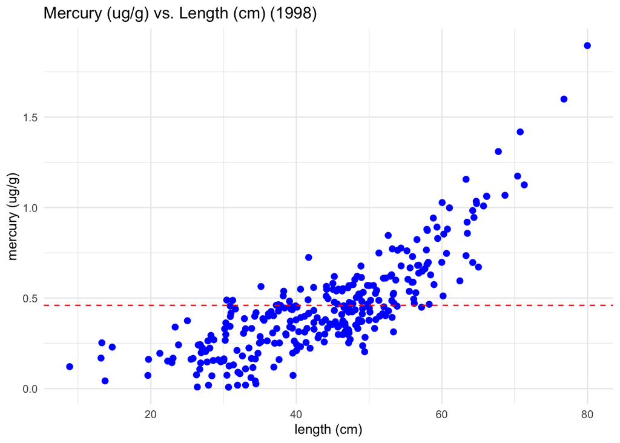

```r
# This line defines a plot, called 'LengthMercury1998', as a ggplot().
# The ggplot() code is a little different from the single variable boxplot.
# Now, we are plotting two columns of the dataset:
# length will be on the (horizontal) x-axis
# mercury will be on the (vertical) y-axis
LengthMercury1998 <- ggplot(fish_1998, aes(x = length, y = mercury)) +
# geom_point() makes a scatterplot.
# We are going to plot the data points in blue
# and a little bigger than the default "size = 2"
  geom_point(color = 'blue', size = 2) +
# Now we're going to write labels for the two axes, and give the graph a title
  xlab("length (cm)")+
  ylab("mercury (ug/g)")+
  ggtitle("Mercury (ug/g) vs. Length (cm) (1998)")+
# As before, we will add a line to represent the EPA's recommended mercury level
# This time, we'll make a red dashed line.
  geom_hline(yintercept = 0.46, linetype= "dashed", color = 'red')+
# We'll use the same theme as last time.
  theme_minimal()


#Because we assigned the graph a label, we have to call that label
LengthMercury1998
```

**Class Questions:**

- What does this tell us about the relationship between fish length and mercury levels?
- Are there certain lengths of fish that have a higher amount of mercury?
- If you caught a fish in 1998, would this graph help you decide whether the fish was safe?

### Lesson 1.4 Recap

In Lesson 1.4 we learned how to:

- plot the distribution and boxplot of a single variable, mercury
- plot a scatter plot of the relationship between two variables, mercury and fish length.

# DAY 2: Did efforts to clean heavy metals improve the healthiness of fish?

## Lesson 1.5: Putting it all together to explore the 2023 fish survey

We will now download and analyze data collected from this second survey (fish_2023.csv).

Our goal is to see how successful the sediment removal efforts by the tribe were in reducing the amount of mercury present in the fish. We will do this by comparing our findings from the 1998 dataset to our current findings in the 2023 dataset.

Today’s exercise allows you to apply the lessons you learned about coding in R from Day 1 to a new dataset.

### Loading in packages and exploring the data

Like we did on Day 1 of the fish module, we first need to load in our datasets before we can explore them!

**NOTE TO SKC/ND DEVELOPERS:** When Day 2 starts, the class might need to take some preliminary steps before they get coding. We should consider:

- Setting the working directory (If we keep the data files in the same directory as this .Rmd file, they can skip this step. Or if you started a project, be sure to check the upper right corner of Rstudio to see that it is open.)
- Clearing the working directory
- These steps are described in the “Module 0” code.

Here is a commented out code chunk, to remind us to address this later…

```r
# getwd()
# setwd()
# list.files()
```

**END NOTE TO SKC/ND DEVELOPERS**

#### Load in packages

We will be using the `tidyverse` packages as we used on Day 1. Since we’ve already installed this package, you just need to activate it for today using the library() command (see below)

Today, we’re also using a new package called `patchwork` This package allows you to plot graphs side-by-side. This will be useful later today, because we want to compare the mercury levels from 1998 side-by-side with those from 2023.

If you want to learn more about `patchwork` click this link: (https://patchwork.data-imaginist.com/)

Since we haven’t installed `patchwork` yet, the code below installs it, then loads the library.

```r
# This loads the "tidyverse" package that you've already installed.
library(tidyverse)

# This installs "patchwork"
if(!require("patchwork")) install.packages("patchwork")
# This loads patchwork into the library, so you can use it in this program.
library(patchwork)
```

#### Load the 2023 fish dataset

The dataset “fish_2023.csv” should be in the same working directory (folder) on your computer as this .Rmd file.

If that’s true, you can import these data into R using the same command that you used to load the 1998 data.

```r
# This code brings the 2023 dataset into RStudio as a dataframe.
fish_2023 <- read.csv("fish_2023.csv", header = TRUE, sep = ',')
```

We will repeat several of the steps we took to investigate the 1998 data with the new 2023, fish data. These steps are important because they allow you to check to see if the data loaded properly; to check to see if they make sense; and to start thinking about their implications for our scientific question, “Did the sediment cleanup efforts help the health of the fish and the community?”

We’ll start by viewing the data:

```r
View(fish_2023)
```

**Write your own code to view the top few lines of the data**

**Class Question:**

- What would go in the parentheses of head() in order to get the output you want?

```r
#Fill in the parentheses:
head()
```

**Class Questions**

- What are the variables that this data set contains?
- In the code below, what would go in the parentheses of dim() in order to learn how many rows and columns the 2023 dataset has?

```r
#Fill in the parentheses with the name of the dataframe for the 2023 fish data
dim()
```

### Descriptive statistics for the 2023 fish data

Now that we have successfully loaded in our data and explored its basic properties, we can now start to explore our data to learn how mercury levels in fish belly fat have changed from 1998 to 2023.

According to the EPA, the maximum safe level of mercury to be consumed is around 0.46 ug/g/day. Tribal fishery managers are interested in how mercury levels in fish belly fat have changed since 1998 to 2023, now that the rivers have been cleaned.

Below, we will analyze data points from the `fish_2023` dataframe to answer these questions. We will start to do this by running some basic summary statistics on the mercury data from 2023.

**Class Question:**

- Work together to write code that tells you the descriptive statistics (median, mean, minimum, meximum, etc) for the mercury in the fish collected in 2023.

```r
# write code for summary statistics here
```

**Question for class:**

- How do the mean and median values of mercury in 2023 compare to the EPA’s standard?
- Do the descriptive statistics suggest that the mercury levels in fish have improved since 1998?

**Recap: How could we communicate these values?**

By running these summary statistics, we can see that mercury levels in fish caught in 2023 are lower than they were in fish that were caught in 1998, which is good news!

However, some fish in 2023 still have unsafe levels of methylmercury. Tribal fisheries managers know that people who catch these fish can’t measure the mercury content, but they can measure the length of the fish they catch.